Promoter mutations in LSCC

Data and code availability Citation

# Genomic landscape of somatic noncoding mutations in LSCC

## Abstract

Genome-wide analysis of paired tumor-normal samples has led to the discovery of driver mutations in protein-coding regions and boosted targeted therapies in lung adenocarcinoma (LUAD). However, noncoding drivers remains poorly understood in lung squamous cell carcinoma (LSCC). By integrative analysis of whole-exome/promoterome, gene and protein expression profiles in 528 patients, we identify a proto-oncogene, WDR74, which harbors a mutational hotspot in its promoter at chr11:62609329 (3.0%, 9/297), leading to overexpression. Electrophoretic mobility shift assay (EMSA) and chromatin immunoprecipitation followed by sequencing (ChIP-seq) demonstrate preferential binding of the transcription factor STAT3 to the mutated allele. Functional experiments using CRISPR-Cas9 gene-edited cell lines provide proof-of-principle support for the biological driver ability in vitro. Our results demonstrate that WDR74 promoter mutations involve in functional consequences and promote tumor development, which improve our understanding of new cancer drivers and implicate the innovative treatment strategies in LSCC.

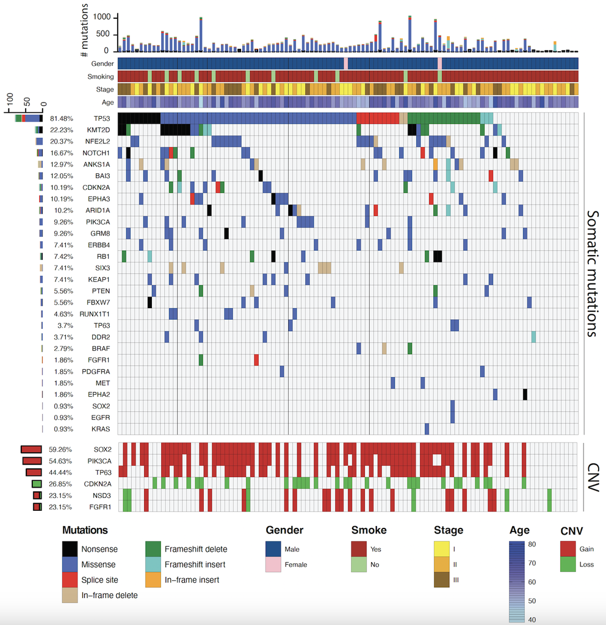

Shanghai Institute of Biochemistry and Cell Biology, Center for Excellence in Molecular Cell Science, CAS